# Project update: Species range shift

Sissi Liu

*Published: march 8, 2024*

### 1 **Summary**

#### 1.1 Main updates since last meeting

- We investigated what had caused anomalous patterns in the previous results and concluded that the anomalies were driven by the terminal effects in the model.
- We eliminate the terminal effects by iterating an infinite game in a time-invariant environment. Previously, the terminal payoffs were based on some arbitrary scrap values.
- Compared two scenarios: with and without side-payments
- Improved code and the model can be run more efficiently.

#### 1.2 Key assumptions about the model: Fixed quota share (FQS)

- We model a **non-adaptive** fishery agreement by assuming catch quota $\sigma_t$ equal to initial stock ownership and is fixed over time: i.e., $\sigma_t=\theta_0$. This implies that cooperation may not be possible if **asymmetry in stock ownership becomes too extreme** .
  - Previously, we assumed that $\sigma_t=\sigma^*$, where $\sigma^*=f(\theta_0|k=0)$, and $\sigma^*\geq\theta_0$
- **Side-payment**: We model side-payments by assuming that a portion of the quota can be fished in the waters of the other country.
- Single-owner optium is used as the reference case to evaluate losses under different scenarios.

### 2 **Update on main results**

#### 2.1 Scenario 1: Fixed quota shares (FQS) + side-payments

With side-payment, the greatest losses occur when:

- the stock-losing country is the major owner, and
- the speed of range shift ($k$) is moderately fast.

*NOTE: Legend text “Ratio” refers to the proportion of loss/gain relative to the sole-owner optium.*

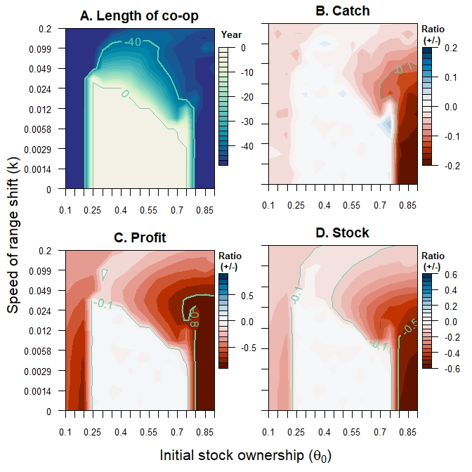

#### 2.2 Scenario 2: FQS but without side payments

The greatest losses happen if:

- the stock-losing country is the minor owner
- the speed of range shift ($k$) is moderately fast.

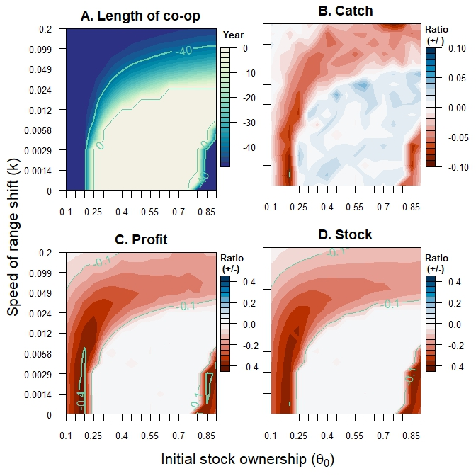

#### 2.3 The effect of side payments

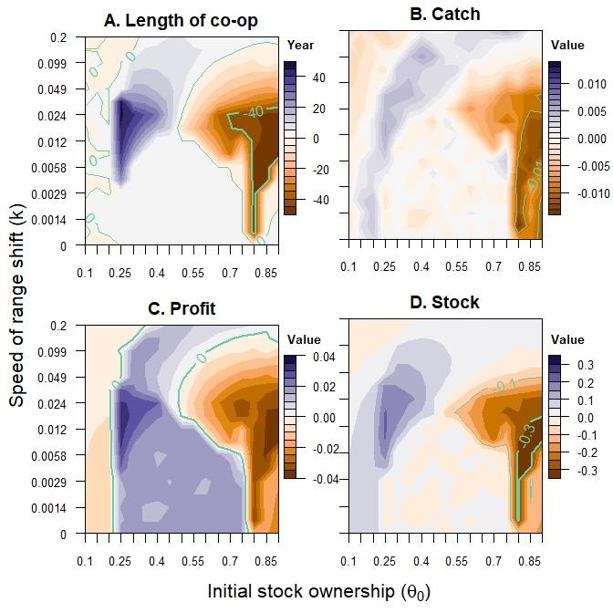

### 3 **Shift of game strategy with $\theta_0$ and $k$**

NOTE:

1. **Blue** denotes the areas where a stock-losing country (#1) wants to defect
2. **Yellow** denotes the areas where a stock-receiving country (#2) wants to defect
3. **Grey** denotes both countries are willing to cooperate.
4. **White & black lines** indicate game strategies and the distribution of stock trajectories in forward realizations.

#### 3.1 Game strategies and stock trajectories WITH side-payment

- $x$ axis =$\theta_0$, $y$ axis=speed of range shift ($k$)

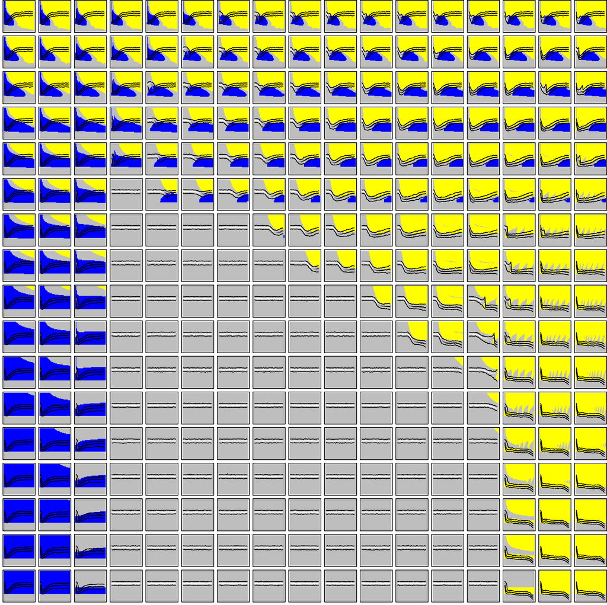

#### 3.2 Game strategies and stock trajectories WITHOUT side-payment

- $x=\theta_0$, $y=$speed of range shift ($k$)

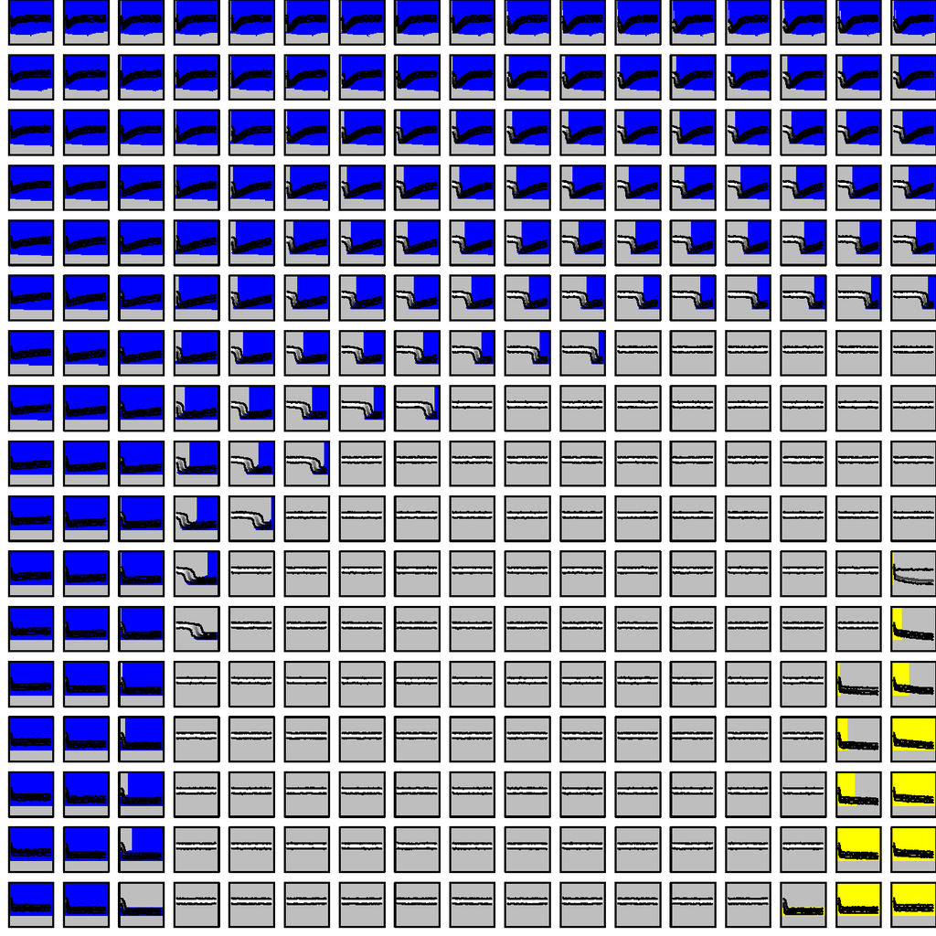

#### 3.3 Optimal harvest strategies with side-payment

NOTE:

1. **h1, h2** refer to harvest proportion ($1-p$) for stock-losing country and stock-receiving country, respectively.
2. **stk** refers to the stock trajectory.
3. dotted **coop** indicates countries are in cooperation ($1=$coop, $0=$ nash)
4. dashed **green** line indicate when $\theta=0.5$, i.e., countries have equal shares.

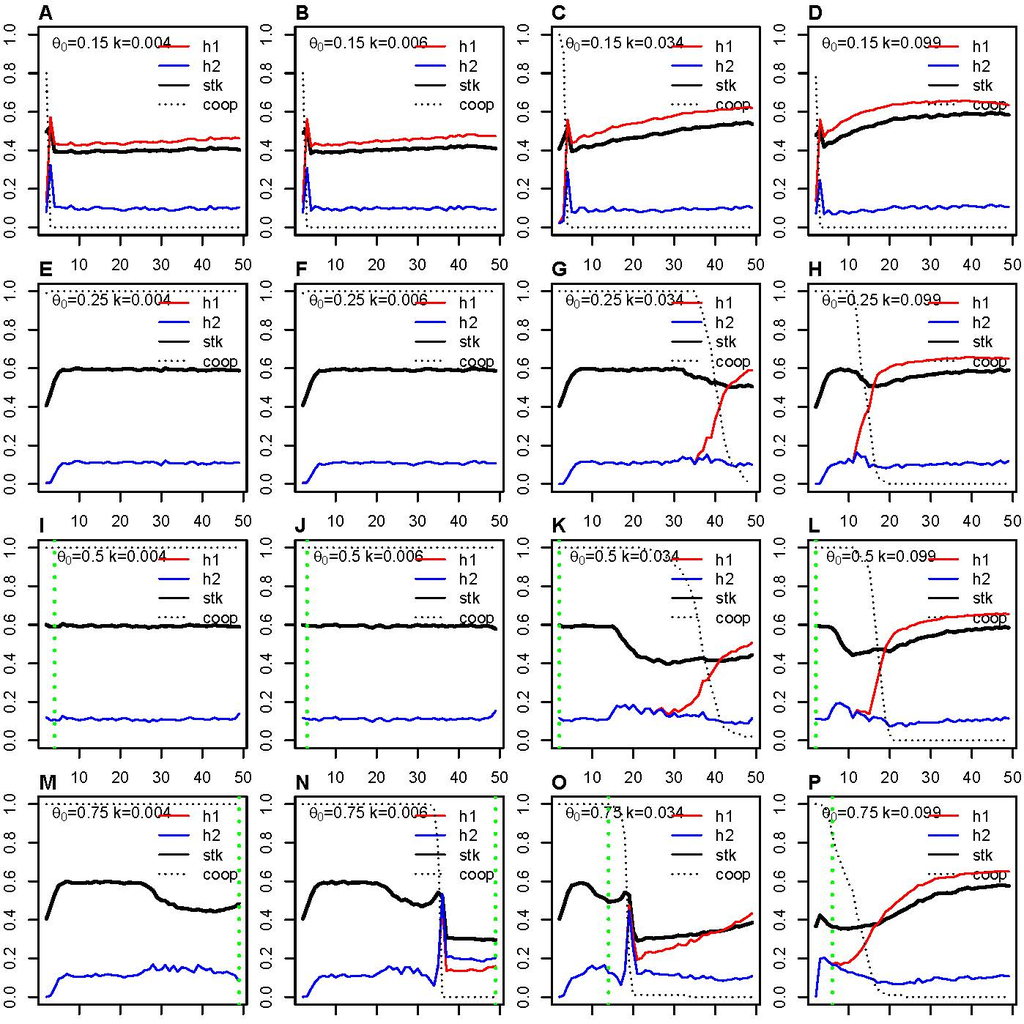

Harvest dynamics result from interplays of the following factors:

- Free-ride incentive: minor owner has more incentive to over-harvest the stock
- Fixed-quota share (FQS): favours the stock-losing country, reduces her incentive to defect.
- FQS + side-payment: side-payment reduces the incentive of stock-receiving country to conserve the stock.

## To do list

- Update species distribution map for the empirical study part.
- Update literature from the last 3 years.